# New York Flights Analysis

2026-02-17

## Executive Summary

This report analyzes over 300.000 fligths from New York in 2013. The goal is to identify factors which influenced filghts departures and evaluate airline performance

Key findings:

1. Best Time to Fly: morning flights are the most punctual
2. Seasonality: Summer months and December provides the highest average delay
3. Weather Influence: Strong correlation between visibility and delay

## Traffic Overview

Before diving into delays, let’s look at the market structure. Who dominates the NYC airspace and where are people flying?

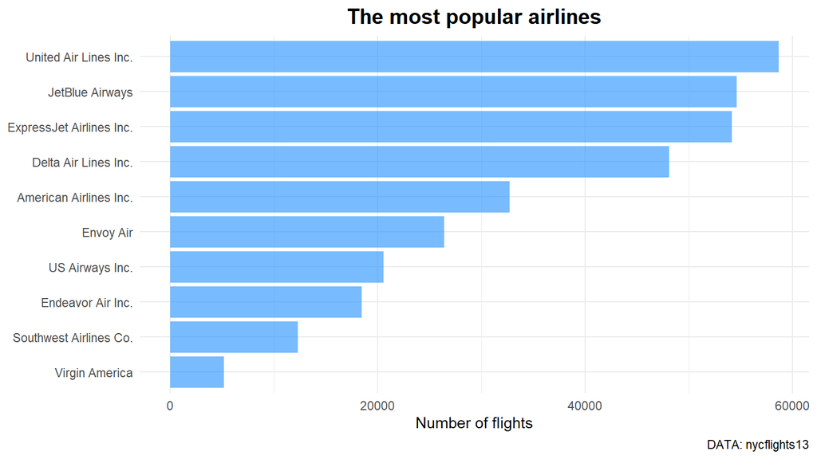

## Traffic Overview

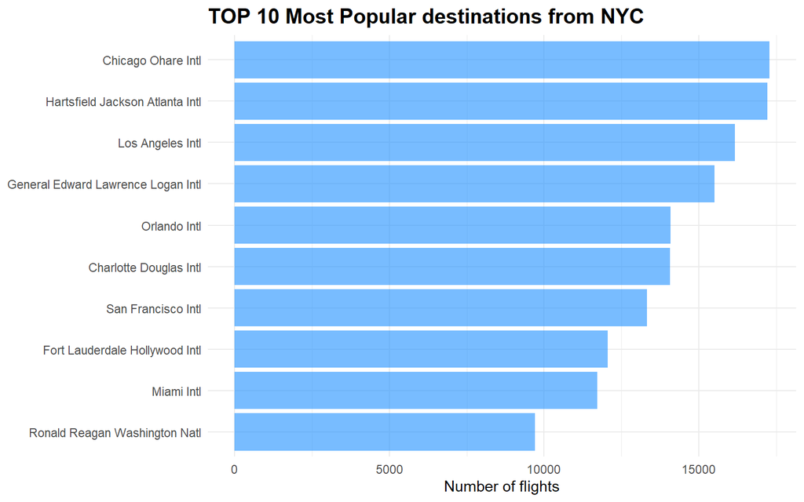

## Timing Analysis: When to Fly?

Timing is one of the most critical factors for passengers. I analyzed delays across different time scales.

The heatmap below reveals a clear pattern: delays accumulate throughout the day.

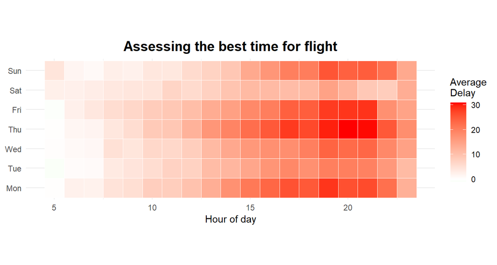

## Seasonal Trends

There is a noticeable spike in delays during the summer holiday season and December.

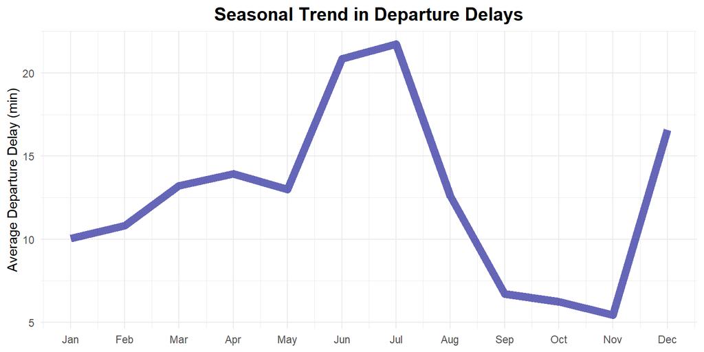

## Airline Performance & Business Model

Punctuality Ranking We evaluated airlines based on arrival delays. A negative value indicates that, on average, the airline arrives ahead of schedule.

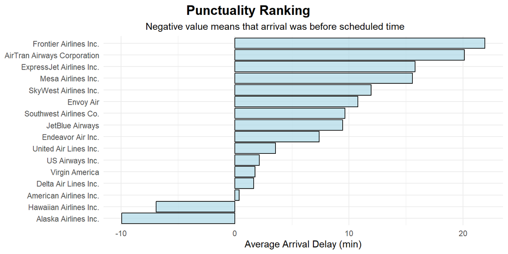

## Operational Range

Understanding the business model: some airlines specialize in short-haul regional flights, while others cover long-distance routes.

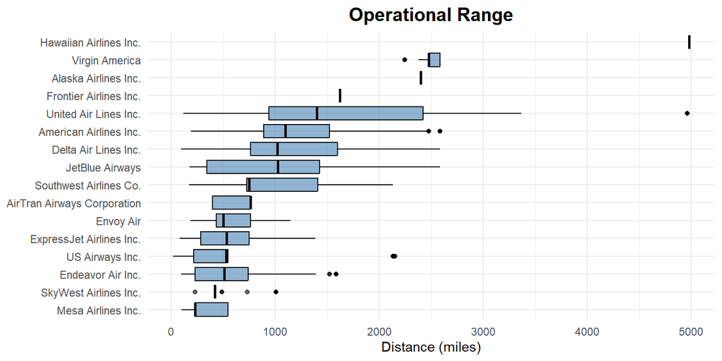

## Technical & Environmental Factors

Impact of Weather (Fog) Visibility is a major constraint for airport operations. The data shows a sharp increase in delays when visibility drops below 2 miles.

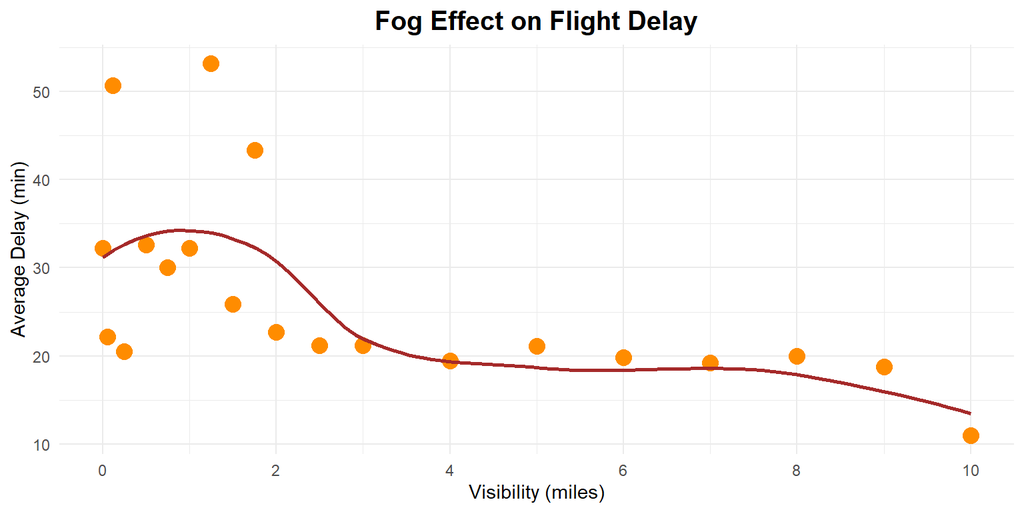

## Plane Age vs Performance

The data indicates **no clear trend** suggesting that plane age is a significant factor. Average delays fluctuate across different ages without a definitive pattern, implying that maintenance schedules likely keep older aircraft just as reliable as newer ones in terms of punctuality.

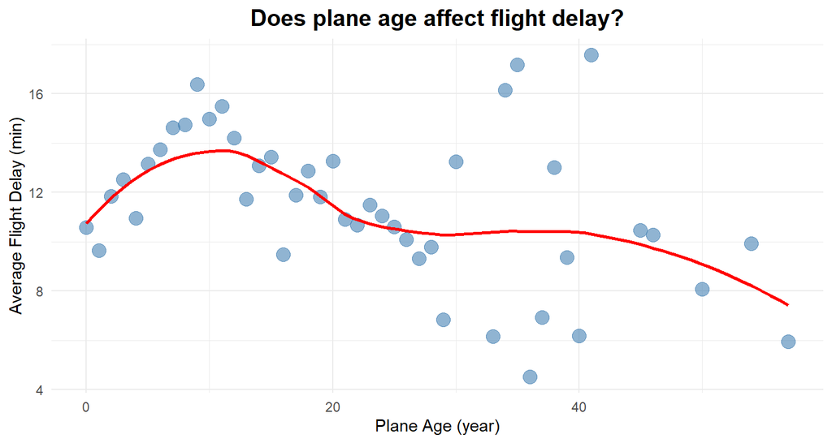